# Iris Classification

Gabe Mednick

6/09/2022

## Iris data

The iris dataset is a classic, so much so that it’s included in the datasets package that comes with every installation of R. You can use `data()` to see a list of all available datasets. Datasets that are associated with packages can be found in a similar way, e.g., `data(package = 'dplyr')`.

Let’s take a look at the data.

```r
# load the iris data set and clean the column names with janitor::clean_names()
iris_df<- iris %>%
  clean_names()

iris_df %>%  head()
```

```
##   sepal_length sepal_width petal_length petal_width species
## 1          5.1         3.5          1.4         0.2  setosa
## 2          4.9         3.0          1.4         0.2  setosa
## 3          4.7         3.2          1.3         0.2  setosa
## 4          4.6         3.1          1.5         0.2  setosa
## 5          5.0         3.6          1.4         0.2  setosa
## 6          5.4         3.9          1.7         0.4  setosa
```

```r
iris_df %>%  count(species)
```

```
##      species  n
## 1     setosa 50
## 2 versicolor 50
## 3  virginica 50
```

```r
# equal number of each species, 150 total

iris_df %>%  str()
```

```
## 'data.frame':    150 obs. of  5 variables:
##  $ sepal_length: num  5.1 4.9 4.7 4.6 5 5.4 4.6 5 4.4 4.9 ...
##  $ sepal_width : num  3.5 3 3.2 3.1 3.6 3.9 3.4 3.4 2.9 3.1 ...
##  $ petal_length: num  1.4 1.4 1.3 1.5 1.4 1.7 1.4 1.5 1.4 1.5 ...
##  $ petal_width : num  0.2 0.2 0.2 0.2 0.2 0.4 0.3 0.2 0.2 0.1 ...
##  $ species     : Factor w/ 3 levels "setosa","versicolor",..: 1 1 1 1 1 1 1 1 1 1 ...
```

The dataset contains three unique species of iris and four variables or features (sepal length and width, and petal length and width). The data is clean but with only 150 observations it’s a wee bit small for training a model. To compensate for this, we will use bootstrap resampling.

#### Outline

**Train a classification model to predict flower species based on the four available features**

The model formula will have the form `species ~ .` where `.` represents all explanatory variables in the data.

# Visualize relationships

Before we do any kind of machine learning, it’s helpful to visualize the data and develop a better understanding of the variables as well as their relationships. This will also give us a stronger intuitive sense about the potential predictive power of the data.

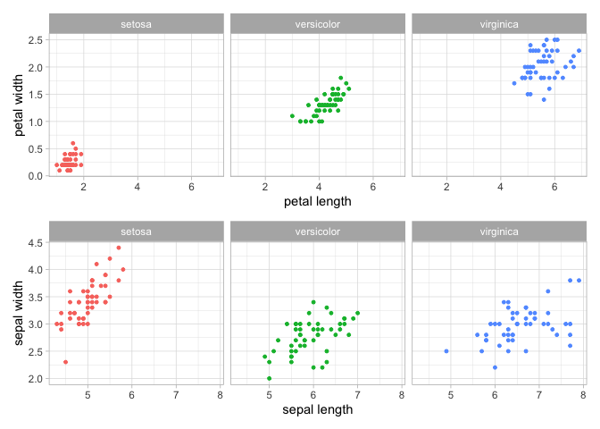

```r
library(ggforce)

sepal <- iris_df %>%
  ggplot(aes(sepal_length, sepal_width, color = species)) +
  geom_point(size = 1) +
  facet_wrap(~species) +
  labs(x = 'sepal length',
       y = 'sepal width') +
  theme(legend.position = 'none')

petal <- iris_df %>%
  ggplot(aes(petal_length, petal_width, color = species)) +
  geom_point(size =1) +
  facet_wrap(~species) +
  labs(x = 'petal length',
       y = 'petal width') +
  theme(legend.position = 'none')

(petal/sepal) # patchwork allows us to arrange plots side-by-side or stacked
```

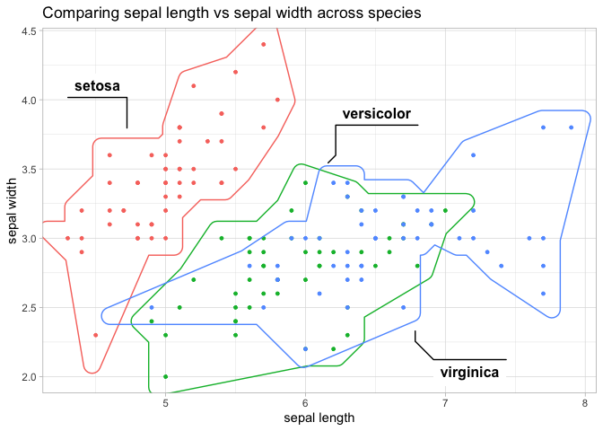

```r
sl_sw <- iris_df %>%
  ggplot(aes(sepal_length, sepal_width, color = species)) +
  geom_point(size = 1) +
  labs(x = 'sepal length',
       y = 'sepal width') +
  theme(legend.position = 'none')

sl_sw +
  geom_mark_hull(
    aes(fill = NULL, label = species),
    concavity = 2) +
  labs(title = "Comparing sepal length vs sepal width across species")
```

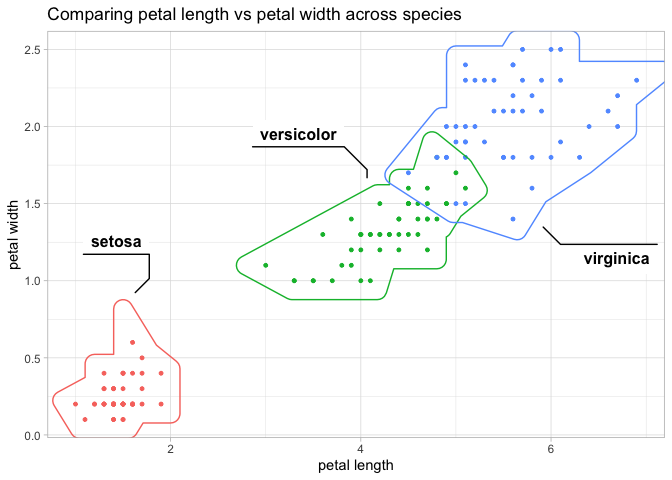

```r
pl_pw <- iris_df %>%
  ggplot(aes(petal_length, petal_width, color = species)) +
  geom_point(size =1) +
  labs(x = 'petal length',
       y = 'petal width') +
  theme(legend.position = 'none')

pl_pw +
  geom_mark_hull(
    aes(fill = NULL, label = species),
    concavity = 2) +
  labs(title = "Comparing petal length vs petal width across species")
```

Let’s change the shape of our data by combining the four iris features into a single column (`metric`) and the associated values will populate a new column (`value`). This transformation into a longer dataset can be achieved with the function `pivot_longer()`.

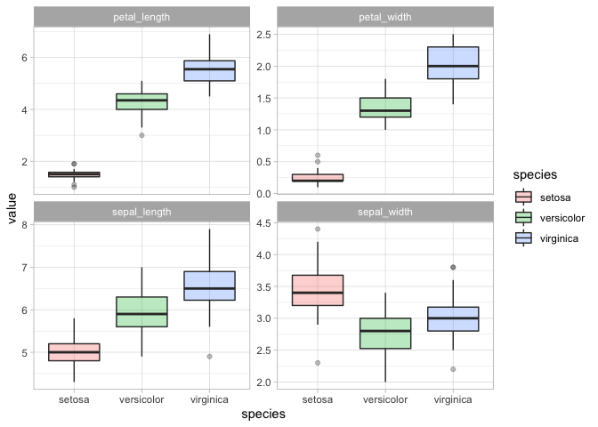

```r
iris_df_long <- iris_df %>%
  pivot_longer(cols = sepal_length:petal_width,
               names_to = 'metric',
               values_to ='value')


# A boxplot is a great way to compare the distribution of each features by species.
iris_df_long %>%
  ggplot(aes(species, value, fill = species)) +
  geom_boxplot(alpha = 0.3) +
  facet_wrap(~ metric, scales = "free_y")
```

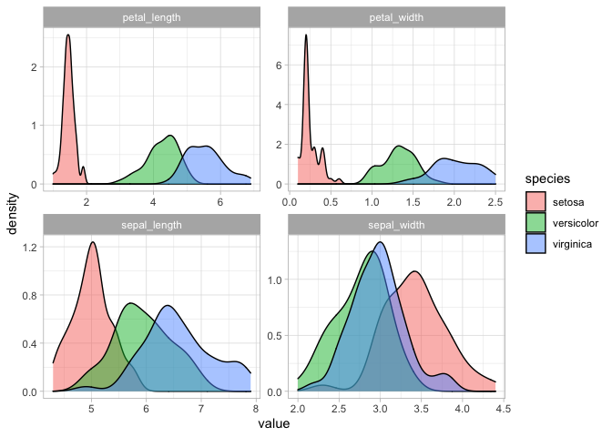

```r
# Looking at the data in a different way, geom_density is a nice alternative to geom_histogram.

iris_df_long %>%
  ggplot(aes(value, fill = species)) +
  geom_density(alpha = .5) +
  facet_wrap(~ metric, scales = "free")
```

## Splitting the data into training and test sets

By default, `initial split()` provides a 75:25 split for our train and test sets respectively. Since our dataset is small to begin with, we are going to make bootstrap resamples from the training data. The function `bootstraps()` will split the data into training and test sets, then repeat this process with replacement a specified number of times (25 is the default).

```r
set.seed(123)
tidy_split <- initial_split(iris_df)
tidy_split
```

```
## <Analysis/Assess/Total>
## <112/38/150>
```

```r
iris_train <- training(tidy_split)
iris_test <- testing(tidy_split)

iris_boots <- bootstraps(iris_train, times = 30)
iris_boots
```

```
## # Bootstrap sampling
## # A tibble: 30 × 2
##    splits           id
##    <list>           <chr>
##  1 <split [112/45]> Bootstrap01
##  2 <split [112/43]> Bootstrap02
##  3 <split [112/39]> Bootstrap03
##  4 <split [112/40]> Bootstrap04
##  5 <split [112/39]> Bootstrap05
##  6 <split [112/41]> Bootstrap06
##  7 <split [112/35]> Bootstrap07
##  8 <split [112/37]> Bootstrap08
##  9 <split [112/42]> Bootstrap09
## 10 <split [112/37]> Bootstrap10
## # … with 20 more rows
```

## Recipes

Recipes is a powerful tool with functions for a wide range of feature engineering tasks designed to prepare data for modeling. Typing `recipes::` into the Rstudio console is a great way to browse the available functions in the package.

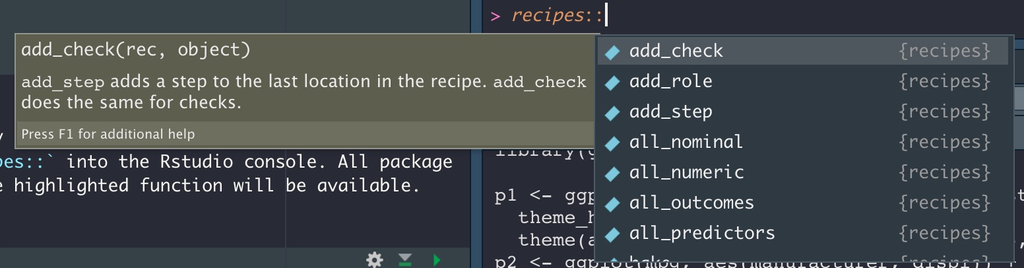

Let’s create a simple recipe to demonstrate optional feature engineering steps for our numeric data.

```r
iris_rec <- recipe(species ~., data = iris_train) %>%
  step_pca(all_predictors()) %>%
  step_normalize(all_predictors())

prep <-  prep(iris_rec)

kable(head(iris_juice <- juice(prep)))
```

| species | PC1 | PC2 | PC3 | PC4 |
| --- | --- | --- | --- | --- |
| setosa | 1.7227690 | 1.2539796 | -0.0911528 | -0.1704339 |
| setosa | 1.2188957 | 1.3368015 | -0.3665258 | 0.1981136 |
| virginica | -2.0712468 | -1.0080369 | 0.9961660 | -1.8706481 |
| setosa | 1.5543285 | 1.2288655 | 0.4323305 | -0.4811825 |
| virginica | -0.4876555 | -0.7920225 | 1.1713477 | -0.9553358 |
| virginica | -0.8207125 | -0.7696463 | 0.5013655 | 0.8697351 |